# Estudiar diferencia en la cantidad de ETAs según magnitud

Enero de 2020

# Cargar datos sismológicos

Sismos vienen con las columnas *Year*, *Month* y *Day*.

```r
sismos <- read.delim("http://anakena.dcc.uchile.cl/~rllull/CC5206/sismos.csv",
                     header = TRUE, sep = ",", quote = "\"", dec = ".", fill = TRUE, comment.char = "#")
```

Los datos de ETA no vienen con esas columnas, pero se pueden generar. Quizás en el futuro las podamos guardar con las columnas generadas.

```r
# Carga de las ETAs
etas <- read.delim("http://anakena.dcc.uchile.cl/~rllull/CC5206/etas2011_2017.csv",
                   header = TRUE, sep = ",", quote = "\"", dec = ".", fill = TRUE, comment.char = "#")

# Agregarle las fechas a las ETAs
agregarFechasEtas <- function(dataframe) {
  fechas <- as.Date(dataframe$Fecha.de.Ingestión, "%d-%m-%Y")
  fechas <- data.frame(Year=as.numeric(format(fechas, format="%Y")),
                       Month=as.numeric(format(fechas, format="%m")),
                       Day=as.numeric(format(fechas, format="%d")))
  fecha_num <- data.frame(num_date=fechas$Year +
                            (fechas$Month-1)/12 +
                            (fechas$Day-1)/24/12)
  fechas <- cbind(fechas, fecha_num)
  cbind(dataframe, fechas)
}
etas <- agregarFechasEtas(etas)
```

# Extracción de los sismos y sus Δs

Se extraen para diferentes magnitudes (5, 6 y 7) e intervalos (de 3, 7, 14 y 30 días). Se crea una función para trabajar los datos más fácil.

```r
generar_datos <- function(sismos, etas, magnitud_min, dias, escribir=TRUE) {
  sismos_mag <- sismos[sismos$Magnitude >= magnitud_min
                       & sismos$Year >= 2011 & sismos$Year <= 2017, ]
  # Generar los dataframes
  # datos es para trabajarlo en el árbol de decisión
  datos <- data.frame(Magnitud = rep(0, nrow(sismos_mag)),
                      Profundidad = rep(0, nrow(sismos_mag)),
                      Region = rep(0, nrow(sismos_mag)),
                      Aumento = rep(0, nrow(sismos_mag)))
  # datos_con_fecha es para trabajarlo en lo que viene
  datos_con_fecha <- data.frame(datos,
                              Año = rep(0, nrow(sismos_mag)),
                              Mes = rep(0, nrow(sismos_mag)))
  for (i in 1:nrow(sismos_mag)) {
    sismo <- sismos_mag[i, ]
    # Tomar los dias días anteriores
    etas_ant <- etas[sismo$num_date - dias/30/12 <= etas$num_date
                     & etas$num_date <= sismo$num_date, ]
    # Tomar los 7 días posteriores
    etas_post <- etas[sismo$num_date < etas$num_date
                      & etas$num_date <= sismo$num_date + dias/30/12, ]
    # La diferencia es la cantidad de columnas de las posteriores menos las anteriores
    dif <- nrow(etas_post) - nrow(etas_ant)

    # Asignar los valores a los datos
    datos[i, ]$Magnitud <- sismo$Magnitude
    datos[i, ]$Profundidad <- sismo$Depth
    datos[i, ]$Region <- sismo$Region_Number
    # A diferencia del Hito 2, se guarda el Δ completo
    datos[i, ]$Aumento <- dif
    # Guardar datos a retornar
    datos_con_fecha[i, ] <- datos[i, ]
    datos_con_fecha[i, ]$Año <- sismo$Year
    datos_con_fecha[i, ]$Mes <- sismo$Month

  }
  # Escribir el csv con los datos obtenidos
  if (escribir) {
    nombre_archivo <- paste("datos_mag", magnitud_min, "_", dias, "d.csv", sep="", collapse=NULL)
    write.csv(datos, nombre_archivo, row.names=FALSE)
  }
  (datos_con_fecha)
}
```

## Magnitud 5

```r
mag5_3d <- generar_datos(sismos, etas, 5, 3)
mag5_7d <- generar_datos(sismos, etas, 5, 7)
mag5_14d <- generar_datos(sismos, etas, 5, 14)
mag5_30d <- generar_datos(sismos, etas, 5, 30)
```

## Magnitud 6

```r
mag6_3d <- generar_datos(sismos, etas, 6, 3)
mag6_7d <- generar_datos(sismos, etas, 6, 7)
mag6_14d <- generar_datos(sismos, etas, 6, 14)
mag6_30d <- generar_datos(sismos, etas, 6, 30)
```

## Magnitud 7

```r
mag7_3d <- generar_datos(sismos, etas, 7, 3)
mag7_7d <- generar_datos(sismos, etas, 7, 7)
mag7_14d <- generar_datos(sismos, etas, 7, 14)
mag7_30d <- generar_datos(sismos, etas, 7, 30)
```

# ¿Cuánto aumento según la región?

Procedemos a hacer un *aggregate* con tal de contar cuánto aumentó, en promedio, por cada magnitud y por cada región. Además, se puede extraer si se aprecia un aumento según cada magnitud y cada intervalo, obteniendo un resultado en cantidad de ETAs registradas posteriores o anteriores al sismo en promedio.

## Magnitud 5 o más

```r
agg_5_3d <- aggregate(Aumento ~ Region, mag5_3d, FUN=mean)
(agg_5_7d <- aggregate(Aumento ~ Region, mag5_7d, FUN=mean))
```

```
##    Region     Aumento
## 1       1  2.90384615
## 2       2  0.04724409
## 3       3 -0.26530612
## 4       4  2.59340659
## 5       5  3.06976744
## 6       6 -5.63636364
## 7       7  1.00000000
## 8       8  3.52380952
## 9       9  2.71428571
## 10     10 -3.50000000
## 11     11  1.22500000
## 12     13 -4.42105263
## 13     15  0.08333333
## 14     16  6.16666667
```

```r
agg_5_14d <- aggregate(Aumento ~ Region, mag5_14d, FUN=mean)
agg_5_30d <- aggregate(Aumento ~ Region, mag5_30d, FUN=mean)
```

Además se puede extraer un aumento promedio para cada intervalo considerado:

```r
mean(mag5_3d$Aumento)
```

```
## [1] 0.6438202
```

```r
mean(mag5_7d$Aumento)
```

```
## [1] 1.277528
```

```r
mean(mag5_14d$Aumento)
```

```
## [1] 2.47191
```

```r
mean(mag5_30d$Aumento)
```

```
## [1] 4.989888
```

## Magnitud 6 o más

```r
agg_6_3d <- aggregate(Aumento ~ Region, mag6_3d, FUN=mean)
(agg_6_7d <- aggregate(Aumento ~ Region, mag6_7d, FUN=mean))
```

```
##    Region    Aumento
## 1       1   4.916667
## 2       2   1.333333
## 3       3 -12.250000
## 4       4   1.739130
## 5       5   8.375000
## 6       7   3.333333
## 7       8   6.333333
## 8       9   1.000000
## 9      10   7.000000
## 10     11  -1.333333
## 11     13  12.000000
## 12     15   1.625000
## 13     16   9.333333
```

```r
agg_6_14d <- aggregate(Aumento ~ Region, mag6_14d, FUN=mean)
agg_6_30d <- aggregate(Aumento ~ Region, mag6_30d, FUN=mean)
```

Extrayendo el aumento promedio para cada intervalo considerado:

```r
mean(mag6_3d$Aumento)
```

```
## [1] 1.02439
```

```r
mean(mag6_7d$Aumento)
```

```
## [1] 2.743902
```

```r
mean(mag6_14d$Aumento)
```

```
## [1] 5.926829
```

```r
mean(mag6_30d$Aumento)
```

```
## [1] 10.23171
```

## Magnitud 7 o más

```r
agg_7_3d <- aggregate(Aumento ~ Region, mag7_3d, FUN=mean)
(agg_7_7d <- aggregate(Aumento ~ Region, mag7_7d, FUN=mean))
```

```
##   Region Aumento
## 1      1      11
## 2      4       7
## 3      7      25
## 4      9       1
## 5     10       7
## 6     15      21
```

```r
agg_7_14d <- aggregate(Aumento ~ Region, mag7_14d, FUN=mean)
agg_7_30d <- aggregate(Aumento ~ Region, mag7_30d, FUN=mean)
```

```r
mean(mag7_3d$Aumento)
```

```
## [1] -0.4444444
```

```r
mean(mag7_7d$Aumento)
```

```
## [1] 11.22222
```

```r
mean(mag7_14d$Aumento)
```

```
## [1] 15.77778
```

```r
mean(mag7_30d$Aumento)
```

```
## [1] 27
```

# ¿Cuánto aumento según la fecha (mes + año)?

Procedemos a hacer un *aggregate* con tal de contar cuánto aumentó, en promedio, por cada mes de cada año.

```r
aggregate(Aumento ~ Mes + Año, mag5_3d, FUN=mean)
```

```
##    Mes  Año    Aumento
## 1    1 2011 -0.7058824
## 2    2 2011  0.9655172
## 3    3 2011 -4.3846154
## 4    4 2011 -1.4545455
## 5    5 2011 -2.7500000
## 6    6 2011 -2.5454545
## 7    7 2011  1.1538462
## 8    8 2011  8.5000000
## 9    9 2011 -0.3750000
## 10  10 2011  1.7333333
## 11  11 2011 -0.8181818
## 12  12 2011  4.2857143
## 13   1 2012 -1.4545455
## 14   2 2012  9.6666667
```

[output cut: 70 more lines]

# Resultados

Los resultados obtenidos sugieren una relación directamente proporcional entre la magnitud mínima de los sismos considerados con la cantidad de días tomados para el intervalo, y la diferencia de ETAs registrados previa o posteriormente al sismo. Se pueden generar gráficos que muestren esto.

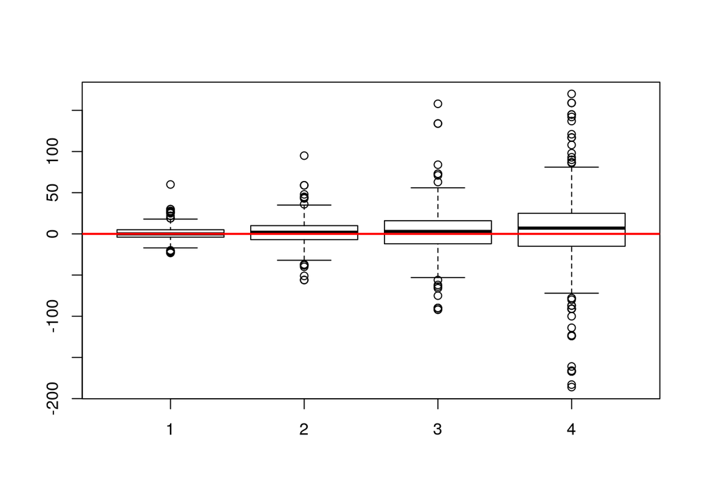

```r
boxplot(mag5_3d$Aumento, mag5_7d$Aumento, mag5_14d$Aumento, mag5_30d$Aumento)
lines(x=c(0, 5), y=rep(0, 2), col="red", lwd=2)
```

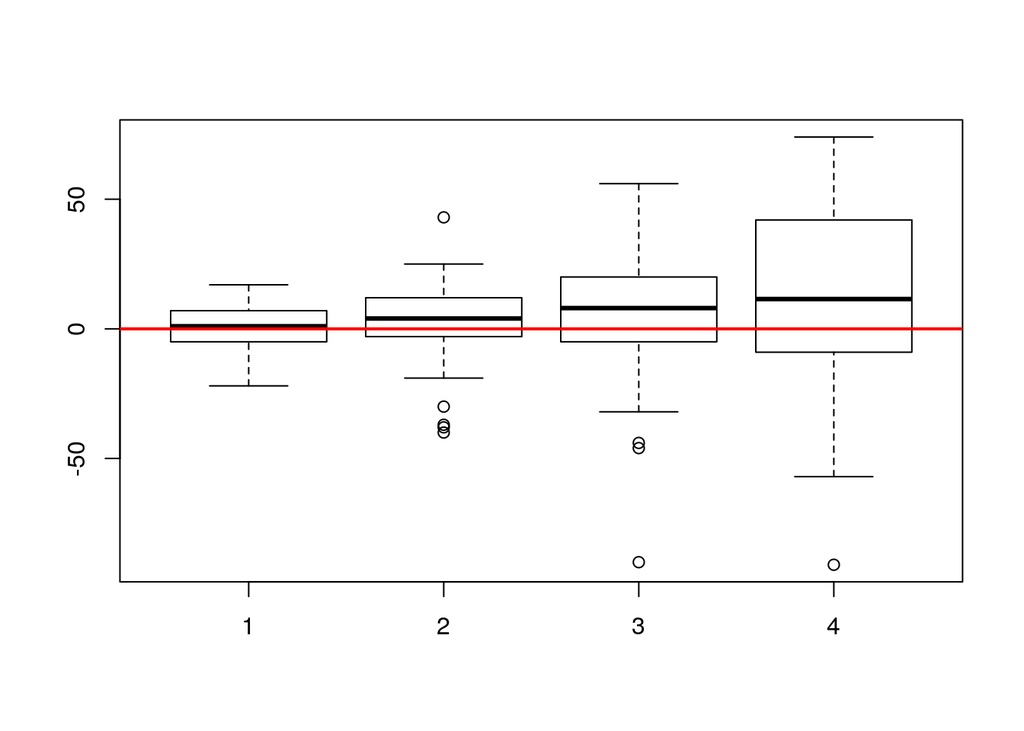

```r
boxplot(mag6_3d$Aumento, mag6_7d$Aumento, mag6_14d$Aumento, mag6_30d$Aumento)
lines(x=c(0, 5), y=rep(0, 2), col="red", lwd=2)
```

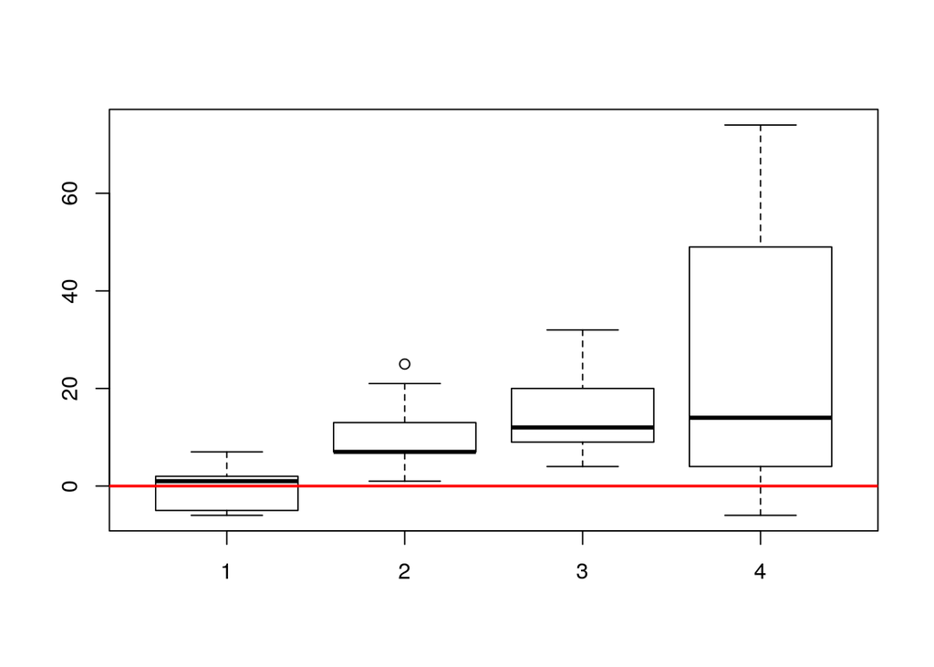

```r
boxplot(mag7_3d$Aumento, mag7_7d$Aumento, mag7_14d$Aumento, mag7_30d$Aumento)
lines(x=c(0, 5), y=rep(0, 2), col="red", lwd=2)
```

# Clustering

Procedemos a realizar un *clustering* a los datos, de tal forma de averiguar si existen grupos de sismos que nos permitan predecir los aumentos o disminuciones.

De los gráficos de caja, se puede extraer que los datos para magnitud 5 no representan tendencias a los aumentos o disminuciones, sino más bien los aumentos van en una distribución normal en torno al 0. Por esta razón, no serán utilizados para esta iteración.

Tampoco se pudo encontrar una verdadera tendencia para los datos que tomaban 3 días solamente. Se procede a trabajar con datos de 7 y 14 días puesto que para 30 días la dispersión es muy alta. Las magnitudes a utilizar serán aquellas mayores o iguales a 6 y a 7.

Genaración de los datos:

```r
# Asume que los nombres vienen en el formato «mag6_3d»
generar_datos_cluster <- function(datos) {
  x <- data.frame(
    Magnitud = datos$Magnitud,
    Profundidad = datos$Profundidad,
    Region = datos$Region,
    Aumento = datos$Aumento
  )
  x
}

x1 <- generar_datos_cluster(mag6_7d)
x2 <- generar_datos_cluster(mag6_14d)
x3 <- generar_datos_cluster(mag7_7d)
x4 <- generar_datos_cluster(mag7_14d)
```

Vemos la cantidad de *clusters* según el método del codo:

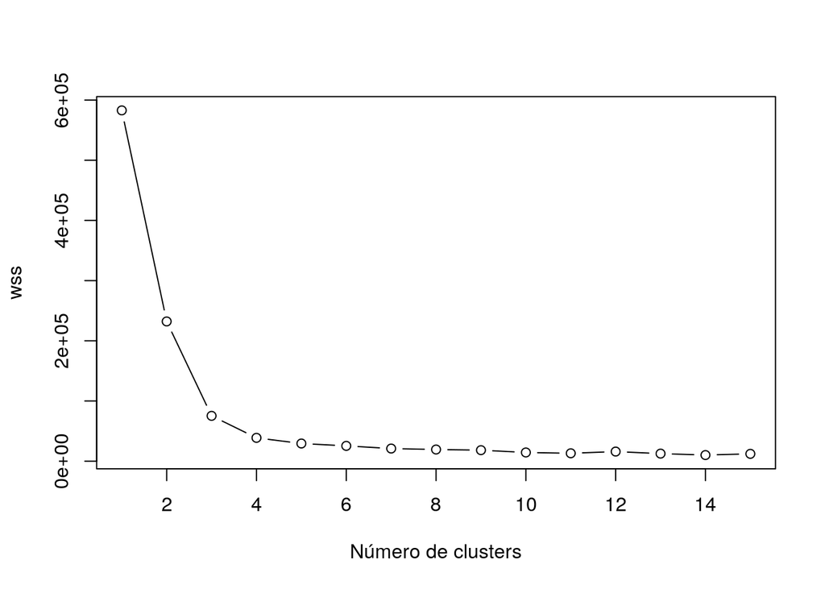

```r
elbow_fun <- function (data) {
  wss <- 0
  for (i in 1:clust){
    wss[i] <- sum(kmeans(data, centers=i)$withinss)
  }
  wss
}


# Método del codo para 15 clusters, sobre el dataset para magnitud 6 y 7 días de intervalo
clust <- 15

wss1 <- elbow_fun(x1)

plot(1:clust, wss1, type="b", xlab="Número de clusters", ylab="wss")
```

Se ve que son 3 *clusters* en el codo, pero por acción experimental, se determinó que lo mejor eran 4 *clusters*.

Notar que el orden generado será magnitud 6, 7 días, luego 6, 14 días, después 7, 7 días y finalmente 7, 14 días.

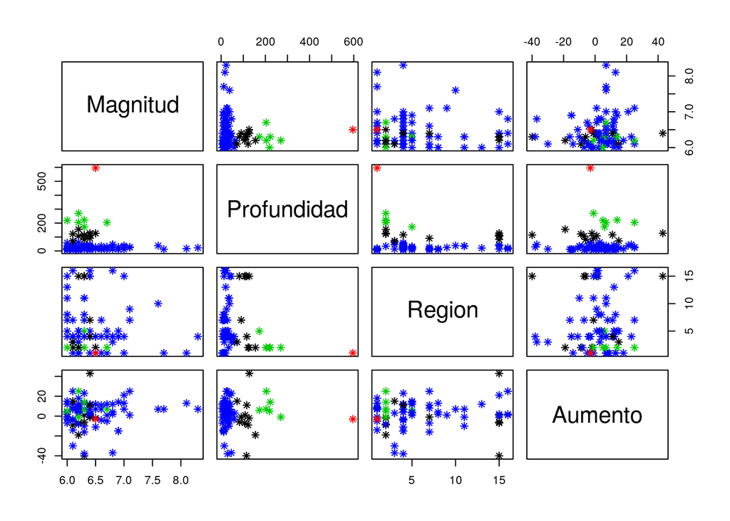

```r
set.seed(3)
cant_clusters <- 4
ns <- 20

km.out1 <- kmeans(x1, cant_clusters, nstart=ns)
km.out2 <- kmeans(x2, cant_clusters, nstart=ns)
km.out3 <- kmeans(x3, cant_clusters, nstart=ns)
km.out4 <- kmeans(x4, cant_clusters, nstart=ns)

pairs(x1, col=km.out1$cluster, pch=8)
```

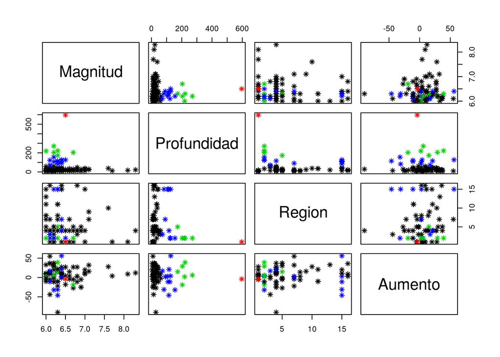

```r
pairs(x2, col=km.out2$cluster, pch=8)
```

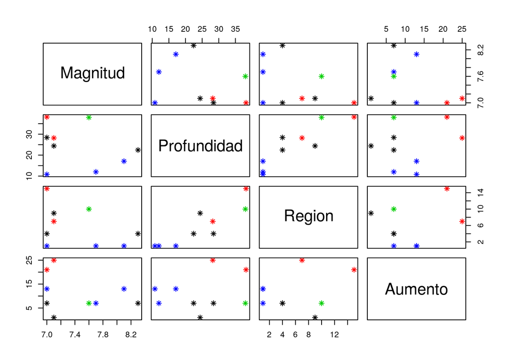

```r
pairs(x3, col=km.out3$cluster, pch=8)
```

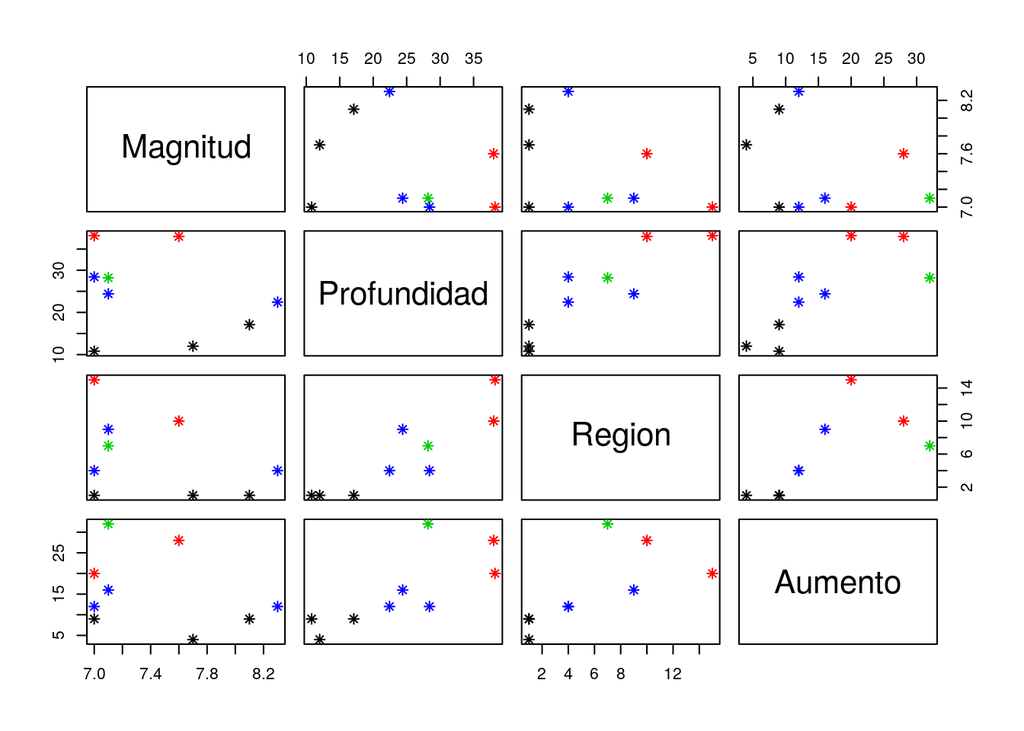

```r
pairs(x4, col=km.out4$cluster, pch=8)
```

Se puede observar que en general para los sismos de magnitud 7, se genera un aumento para cualquier magnitud, produndidad o región. Esto coincide con las predicciones del clasificador, que dicen que para sismos de mangitud 7 o más, sí o sí aumentan los reportes de ETAs.

## Clustering Jerárquico Aglomerativo

Se pensó en esta manera pensando en que los resultados pueden estar distribuidos como árbol.

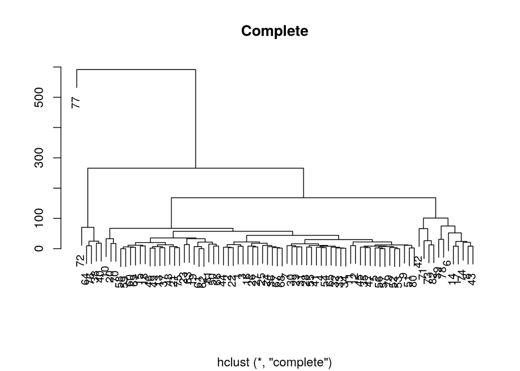

```r
# Recordar que x1 es magnitud 6 a 7 días de intervalo
hc.complete <- hclust(dist(x1), method = "complete")
hc.single <- hclust(dist(x1), method = "single")
hc.average <- hclust(dist(x1), method = "average")

#par(mfrow=c(1,3))
plot(hc.complete, main="Complete", xlab="", ylab="", cex=.9)
```

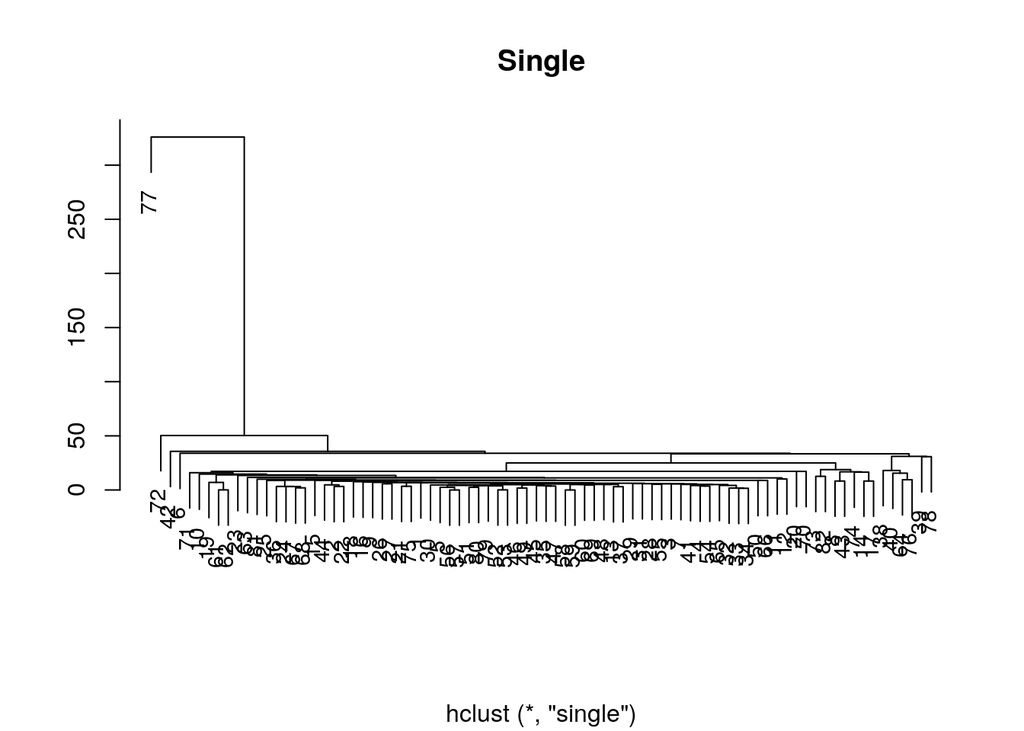

```r
plot(hc.single, main="Single", xlab="", ylab="", cex=.9)
```

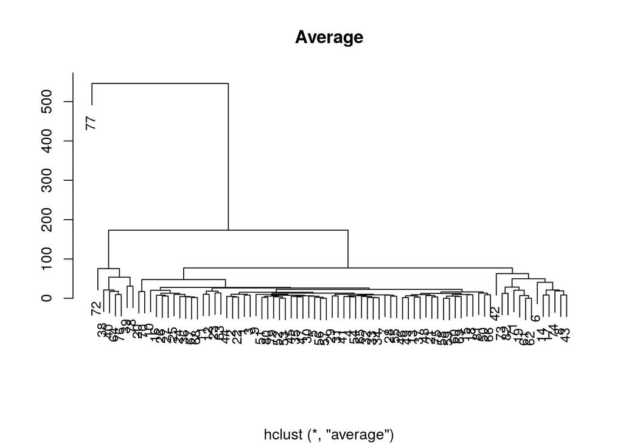

```r
plot(hc.average, main="Average", xlab="", ylab="", cex=.9)
```

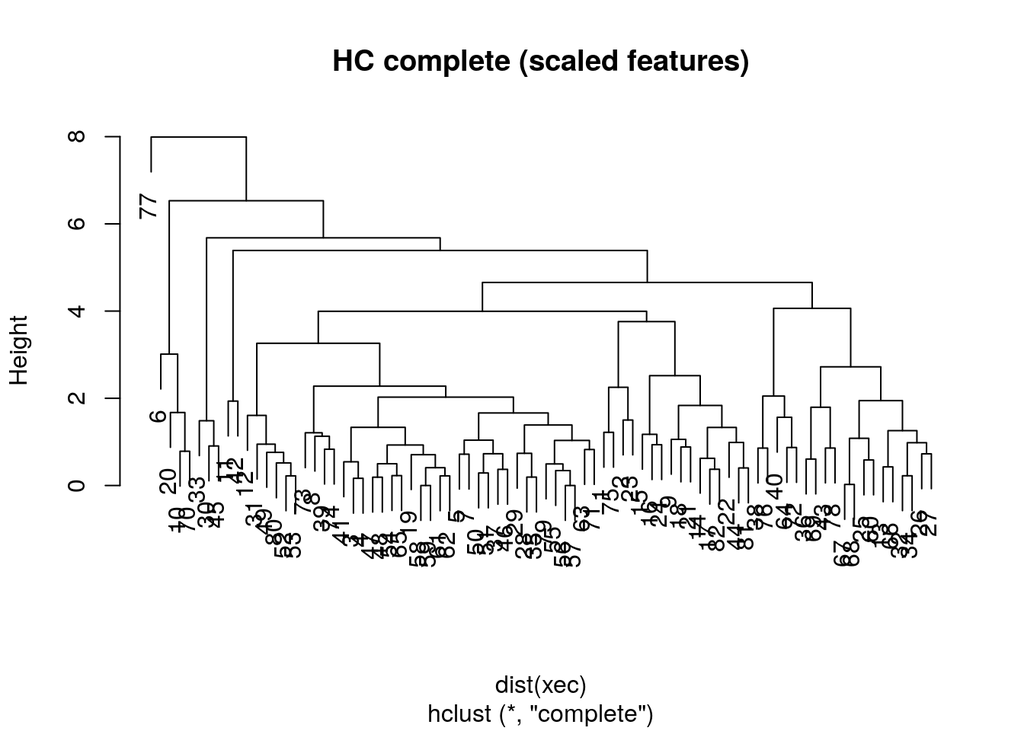

```r
xec <- scale(x1)
plot(hclust(dist(xec), method = "complete"), main = "HC complete (scaled features)")
```